# LotkaVolterra

Hans W. Borchers

2021-02-04

## Differential Equations with Julia

### Systems of Equations

The **Lotka-Volterra** equations attempt to describe the dynamics of biological systems in which two species interact, one as a predator and the other as prey. Here it is assumed that the habitat is largely isolated.

The model consists of two intermingled differential equations of first order.

$$dy1/dt = p_1 \, y_1 + p_2 \, y_1 y_2$$
$$dy2/dt = p_3 \, y_2 + p_4 \, y_1 y_2$$

Here $y_1$ is the number of prey (‘rabbits’), $y_2$ the number of some predator (‘foxes’). The coefficients characterize the interaction between the two species. For instance, $p_3$ should be negative as the predator will die out if there is no prey.

We define a function that returns the two derivatives:

```r
f <- function(u, p, t) {
    du1 <- p1 * u[1] + p2 * u[1] * u[2]
    du2 <- p3 * u[2] + p4 * u[1] * u[2]
    return( c(du1, du2) )
}
```

with parameters `p1, ..., p4` and time span `[0, 240]` (of weeks or months, for example) and an initial population of `y0 <- c(50, 15)` (in thousands, say).

```r
p1 <-  0.1;  p2 <- -0.01
p3 <- -0.05; p4 <-  0.001
u0 <- c(50, 15)
tspan <- c(0, 240)
```

```r
library(JuliaCall)
julia_setup()
```

```
## Julia version 1.5.3 at location /usr/bin will be used.
```

```
## Loading setup script for JuliaCall...
```

```
## Finish loading setup script for JuliaCall.
```

```r
library(diffeqr)
de <- diffeqr::diffeq_setup()
```

We assign the time point at which a solution shall be returned (to make the plotted function smoother) and call Julia’s Differential Equation solver as before.

```r
t <- seq(0, 240, by=2)

prob <- de$ODEProblem(f, u0, tspan)
sol <- de$solve(prob, rel.tol = 1e-08, saveat = t)

# Convert Julia object into an R matrix
y <- sapply(sol$u,identity)
```

For systems of equations the solution is returned as an array of arrays. We convert it into an R matrix with rows representing the time series solving the problem.

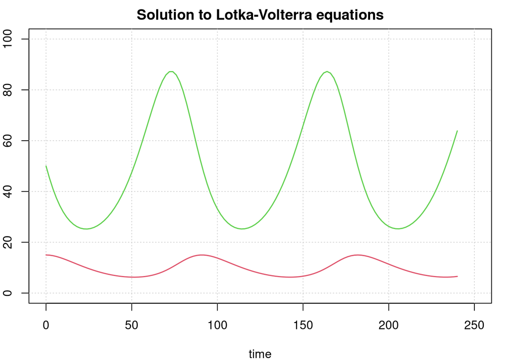

```r
par(mar=c(4, 2, 2, 1))
plot(0, 0, type = 'n', xlim = c(0, 250), ylim = c(0, 100),
     xlab = 'time', ylab = '',
     main = 'Solution to Lotka-Volterra equations')
grid()

lines(t, y[1, ], col = 3, lwd = 1.5)
lines(t, y[2, ], col = 2, lwd = 1.5)
```

The green line displays prey figures, the red line the predators. Both species develop in a periodic way, but the curves are not sine curves, actually they cannot be represented through elementary mathematical functions.

### Second-order Differential Equations

Differential Equations of second order, $y'' = f(t, y, y')$, cannot be solved directly, instead we solve them as a system of two first order equations with $y_1 = y, y_2 = y'$, rewritng the above equation as
$$dy_1/dt = y_2$$
$$dy_2/dt = f(t, y_1, y_2)$$

As an example, we look at a (mathematical) pendulum. Newtonian Physics tell us that the pendulum swings according to the equation
$$\frac{d^2 u}{dt^2} = - \frac{g}{L} \sin(u)$$
where $g$ is the gravity acceleration (on earth), $L$ the length of the pendulum, and $u$ the elongation from the vertical direction.

```r
g <- 9.81  # [m/s^2]
L <- 1.0   # [m]
```

Following the ‘trick’ above function `f` looks as

```r
f <- function(u, p, t) {
    du1 <- u[2]               # u1' = u'  = u2
    du2 <- -g/L * sin(u[1])   # u2' = u'' = -g/L sin(u)
    return( c(du1, du2) )
}
```

We solve this system as we did before. Start with an elongation of 45 degrees (and no velocity) and observe for 10 seconds.

```r
u0 <- c(pi/4, 0)
tspan <- c(0, 10)
t <- seq(0, 10, length = 100)

prob <- de$ODEProblem(f, u0, tspan)
sol <- de$solve(prob, rel.tol = 1e-08, saveat = t)

# Convert Julia object into an R matrix
y <- sapply(sol$u,identity)
```

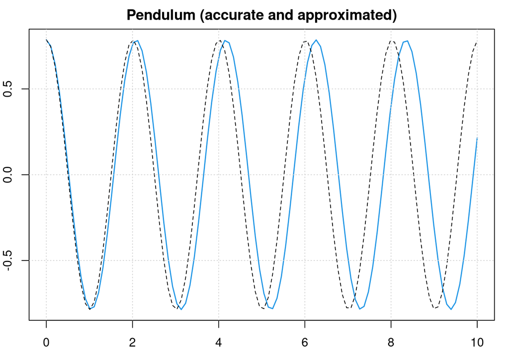

```r
u <- y[1, ]     # elongation
v <- y[2, ]     # angular velocity

par(mar = c(3,2,2,1))
plot(t, u, type = 'l', col = 4, lwd = 1.5,
     main = "Pendulum (accurate and approximated)")
lines(t, pi/4 * sin(sqrt(g/L)*t + pi/2), lty = 2)
grid()
```

The pendulum swings back-and-forth with a frequency of about 2 seconds.

We can see that the approximated solution is oscillating slightly faster.